# Exercise #X

## Exercise 3: Baby-Names in Munich (3.5 Points)

Download the latest open datasets on given names (“Vornamen”) from the open data repository of the city of Munich for the years `2023` and `2022`.

Link: https://opendata.muenchen.de/dataset/vornamen-von-neugeborenen

1. Download the data for both years and track it in git. For small datasets like these adding them to git is not a problem.
2. Load the data for both years into R. Check the type of the count variable (“Anzahl”) and look into the data to determine why it is not numeric? Fix the problem in an appropriate manner, it is OK if some of the counts are inaccurate because of this. Explain your solution and the repercussions.

   ```r
   #Loading required libraries
   library(readr)
   library(dplyr)
   #Loading data
   vornamen_2023 <- read_csv("/Users/hannahstrobel/Documents/Studium/8_Semester/2_stat_Software/0_Graded_Excercises/3_Ex/2024-exeRcise-sheet-3/vornamen-muenchen-2023.csv")
   vornamen_2022 <- read_csv("/Users/hannahstrobel/Documents/Studium/8_Semester/2_stat_Software/0_Graded_Excercises/3_Ex/2024-exeRcise-sheet-3/vornamen-muenchen-2022.csv")

   #Overview
   str(vornamen_2022)
   ```

   ```
   spc_tbl_ [4,390 × 3] (S3: spec_tbl_df/tbl_df/tbl/data.frame)
    $ Vorname   : chr [1:4390] "Emilia" "Emma" "Mia" "Sophia" ...
    $ Anzahl    : chr [1:4390] "103" "101" "93" "78" ...
    $ Geschlecht: chr [1:4390] "w" "w" "w" "w" ...
    - attr(*, "spec")=
     .. cols(
     ..   Vorname = col_character(),
     ..   Anzahl = col_character(),
     ..   Geschlecht = col_character()
     .. )
    - attr(*, "problems")=<externalptr>
   ```

   ```r
   head(vornamen_2022, 10)
   ```

   ```
   # A tibble: 10 × 3
      Vorname Anzahl Geschlecht
      <chr>   <chr>  <chr>
    1 Emilia  103    w
    2 Emma    101    w
    3 Mia     93     w
    4 Sophia  78     w
    5 Anna    72     w
    6 Lea     71     w
    7 Mila    71     w
    8 Clara   67     w
    9 Sophie  65     w
   10 Helena  61     w
   ```

   ```r
   str(vornamen_2023)
   ```

   ```
   spc_tbl_ [4,289 × 3] (S3: spec_tbl_df/tbl_df/tbl/data.frame)
    $ Vorname   : chr [1:4289] "Leon" "Maximilian" "Emilia" "Paul" ...
    $ Anzahl    : chr [1:4289] "107" "105" "89" "89" ...
    $ Geschlecht: chr [1:4289] "m" "m" "w" "m" ...
    - attr(*, "spec")=
     .. cols(
     ..   Vorname = col_character(),
     ..   Anzahl = col_character(),
     ..   Geschlecht = col_character()
     .. )
    - attr(*, "problems")=<externalptr>
   ```

   ```r
   head(vornamen_2023, 10)
   ```

   ```
   # A tibble: 10 × 3
      Vorname    Anzahl Geschlecht
      <chr>      <chr>  <chr>
    1 Leon       107    m
    2 Maximilian 105    m
    3 Emilia     89     w
    4 Paul       89     m
    5 Noah       83     m
    6 Anton      80     m
    7 Jakob      80     m
    8 Felix      78     m
    9 Leo        74     m
   10 Elias      72     m
   ```

   ```r
   #Examination of 'Anzahl'
   head(vornamen_2022$Anzahl,10)
   ```

   ```
    [1] "103" "101" "93"  "78"  "72"  "71"  "71"  "67"  "65"  "61"
   ```

   ```r
   head(vornamen_2023$Anzahl,10)
   ```

   ```
    [1] "107" "105" "89"  "89"  "83"  "80"  "80"  "78"  "74"  "72"
   ```

   ```r
   #Removing non-numeric characters from the ‘Anzahl’ column and converting them to numeric values

   vornamen_2023 <- vornamen_2023 %>%
     mutate(Anzahl = as.numeric(gsub("[^0-9]", "", Anzahl)))

   vornamen_2022 <- vornamen_2022 %>%
     mutate(Anzahl = as.numeric(gsub("[^0-9]", "", Anzahl)))


   #Review
   head(vornamen_2023,10)
   ```

   ```
   # A tibble: 10 × 3
      Vorname    Anzahl Geschlecht
      <chr>       <dbl> <chr>
    1 Leon          107 m
    2 Maximilian    105 m
    3 Emilia         89 w
    4 Paul           89 m
    5 Noah           83 m
    6 Anton          80 m
    7 Jakob          80 m
    8 Felix          78 m
    9 Leo            74 m
   10 Elias          72 m
   ```

   ```r
   head(vornamen_2022,10)
   ```

   ```
   # A tibble: 10 × 3
      Vorname Anzahl Geschlecht
      <chr>    <dbl> <chr>
    1 Emilia     103 w
    2 Emma       101 w
    3 Mia         93 w
    4 Sophia      78 w
    5 Anna        72 w
    6 Lea         71 w
    7 Mila        71 w
    8 Clara       67 w
    9 Sophie      65 w
   10 Helena      61 w
   ```

   *The solution is to remove all non-numeric characters from the ‘Anzahl’ column and convert the cleaned values into numeric values.*

   *Repercussions*
   1. Data Loss:  
      This approach will remove all the characters that are not numeric (e.g. ‘4 oder weniger’) and will only keep the numeric parts. This means that ‘4 oder weniger’ will become ‘4’, resulting in a loss of data.
   2. Inaccuracies:  
      On top of that some values could be changed during the cleanup, which could lead to inaccuracies. For example there could be an overestimation or underestimation of the actual number.
   3. Incorrect Values:  
      If there are values that are completely non-numeric and are therefore converted to ‘NA’, this could affect the data analysis if these missing values are not handled correctly.  
      Despite these repercussions, this cleaning is often necessary to bring the data into a usable form.
3. Calculate the total number of babies born in Munich in 2022 and 2023. Which year had the bigger baby-boom?

   ```r
   #Total number of babies 2023
   total_2023 <- sum(vornamen_2023$Anzahl, na.rm = TRUE)
   #Total number of babies 2022
   total_2022 <- sum(vornamen_2022$Anzahl, na.rm = TRUE)
   #Showing results
   total_2023
   ```

   ```
   [1] 24229
   ```

   ```r
   total_2022
   ```

   ```
   [1] 25199
   ```

   *The higher baby boom was in 2022.*
4. Add a new column `year` to both datasets which holds the correct year for each.

   ```r
   #Inserting 'year' to the datasets
   vornamen_2023 <- vornamen_2023 %>% mutate(year = 2023)
   vornamen_2022 <- vornamen_2022 %>% mutate(year = 2022)

   #Checking the columns
   head(vornamen_2023, 10)
   ```

   ```
   # A tibble: 10 × 4
      Vorname    Anzahl Geschlecht  year
      <chr>       <dbl> <chr>      <dbl>
    1 Leon          107 m           2023
    2 Maximilian    105 m           2023
    3 Emilia         89 w           2023
    4 Paul           89 m           2023
    5 Noah           83 m           2023
    6 Anton          80 m           2023
    7 Jakob          80 m           2023
    8 Felix          78 m           2023
    9 Leo            74 m           2023
   10 Elias          72 m           2023
   ```

   ```r
   head(vornamen_2022, 10)
   ```

   ```
   # A tibble: 10 × 4
      Vorname Anzahl Geschlecht  year
      <chr>    <dbl> <chr>      <dbl>
    1 Emilia     103 w           2022
    2 Emma       101 w           2022
    3 Mia         93 w           2022
    4 Sophia      78 w           2022
    5 Anna        72 w           2022
    6 Lea         71 w           2022
    7 Mila        71 w           2022
    8 Clara       67 w           2022
    9 Sophie      65 w           2022
   10 Helena      61 w           2022
   ```

5. Combine both datasets into one using `bind_rows()`.

   ```r
   #Combining both datasets
   combined_dataset <- bind_rows(vornamen_2023, vornamen_2022)
   head(combined_dataset,10)
   ```

   ```
   # A tibble: 10 × 4
      Vorname    Anzahl Geschlecht  year
      <chr>       <dbl> <chr>      <dbl>
    1 Leon          107 m           2023
    2 Maximilian    105 m           2023
    3 Emilia         89 w           2023
    4 Paul           89 m           2023
    5 Noah           83 m           2023
    6 Anton          80 m           2023
    7 Jakob          80 m           2023
    8 Felix          78 m           2023
    9 Leo            74 m           2023
   10 Elias          72 m           2023
   ```

6. Combine the counts for same names to determine the most popular names across both years. Print out the top 10 names in a nicely formatted table for both years. Include a table caption.

   ```r
   #Loading required library
   library(knitr)

   #Group by name and adding up the number of occurrences
   popular_names <- combined_dataset %>% group_by(Vorname) %>% summarise(Total_Count = sum(Anzahl, na.rm = TRUE)) %>% arrange(desc(Total_Count))
   #Printing the top 10 names
   top_names <- popular_names %>% slice_head(n = 10)

   #Formatted table with caption
   cat("### Top 10 Names:\n")
   ```

   ```
   ### Top 10 Names:
   ```

   ```r
   kable(top_names, caption = "Top 10 Names with their Total Counts")
   ```

   Table 1: Top 10 Names with their Total Counts

   | Vorname | Total_Count |
   | --- | --- |
   | Maximilian | 209 |
   | Emilia | 192 |
   | Leon | 188 |
   | Anton | 181 |
   | Emma | 172 |
   | Felix | 166 |
   | Mia | 163 |
   | Paul | 161 |
   | Noah | 159 |
   | Jonas | 158 |

## Exercise 4: Open Analysis (4 points)

This exercise is a bit more open-ended. You can choose any dataset from [Our World in Data](https://ourworldindata.org/) and analyze it, while determining the research question yourself.

1. Go to https://github.com/owid/owid-datasets/tree/master/datasets and choose a dataset that interests you. You can have a look at https://ourworldindata.org/ to gather some inspiration.
2. Download the dataset and track it in git.
3. Put the name / title of the dataset and a link to it below.
- *Dataset Name: LGBT Marital Status in the US (Gallup 2017)*
- *Link:* https://github.com/owid/owid-datasets/tree/master/datasets/LGBT%20Marital%20Status%20in%20the%20US%20(Gallup%202017)
4. Come up with a (research) question you want to answer with the data and briefly explain why you believe this is an interesting question within one sentence. It should be a question that can be answered with the dataset and using R.

   *Research Question*

   *How has the marriage status of LGBT people in the USA changed between 2015 and 2017?*

   *Explanation*  
   *Understanding the dynamics of marriage status among LGBT individuals over this time frame provides valuable insights into the progress of legal recognition and societal acceptance of same-sex relationships, reflecting broader shifts in attitudes and policies toward LGBTQ+ rights in the United States.*
5. Use R to answer your chosen question.

   ```r
   #Loading dataset
   lgbt_mariage <- read_csv("//Users/hannahstrobel/Documents/Studium/8_Semester/2_stat_Software/0_Graded_Excercises/3_Ex/2024-exeRcise-sheet-3/LGBT Marital Status in the US (Gallup 2017).csv")

   #Exploring the structure
   str(lgbt_mariage)
   ```

   ```
   spc_tbl_ [3 × 10] (S3: spec_tbl_df/tbl_df/tbl/data.frame)
    $ Entity                                  : chr [1:3] "United States" "United States" "United States"
    $ Year                                    : num [1:3] 2015 2016 2017
    $ % LGBT Married to same-sex spouse       : num [1:3] 7.9 9.6 10.2
    $ % LGBT Living with same-sex partner     : num [1:3] 12.8 10.1 6.6
    $ % LGBT Single/Never married             : num [1:3] 47.4 49.9 55.7
    $ % LGBT  Living with opposite-sex partner: num [1:3] 4.8 5 4.2
    $ % LGBT Married to opposite-sex spouse   : num [1:3] 14.2 13.6 13.1
    $ % LGBT Divorced                         : num [1:3] 7.1 6.4 5.4
    $ % LGBT Separated                        : num [1:3] 2.5 2.2 2.1
    $ % LGBT Widowed                          : num [1:3] 2.8 2.9 2.2
    - attr(*, "spec")=
     .. cols(
     ..   Entity = col_character(),
     ..   Year = col_double(),
     ..   `% LGBT Married to same-sex spouse` = col_double(),
     ..   `% LGBT Living with same-sex partner` = col_double(),
     ..   `% LGBT Single/Never married` = col_double(),
     ..   `% LGBT  Living with opposite-sex partner` = col_double(),
     ..   `% LGBT Married to opposite-sex spouse` = col_double(),
     ..   `% LGBT Divorced` = col_double(),
     ..   `% LGBT Separated` = col_double(),
     ..   `% LGBT Widowed` = col_double()
     .. )
    - attr(*, "problems")=<externalptr>
   ```

   ```r
   head(lgbt_mariage)
   ```

   ```
   # A tibble: 3 × 10
     Entity         Year % LGBT Married to same-…¹ % LGBT Living with s…²
     <chr>         <dbl>                     <dbl>                  <dbl>
   1 United States  2015                       7.9                   12.8
   2 United States  2016                       9.6                   10.1
   3 United States  2017                      10.2                    6.6
   # ℹ abbreviated names: ¹`% LGBT Married to same-sex spouse`,
   #   ²`% LGBT Living with same-sex partner`
   # ℹ 6 more variables: `% LGBT Single/Never married` <dbl>,
   #   `% LGBT  Living with opposite-sex partner` <dbl>,
   #   `% LGBT Married to opposite-sex spouse` <dbl>,
   #   `% LGBT Divorced` <dbl>, `% LGBT Separated` <dbl>,
   #   `% LGBT Widowed` <dbl>
   ```

   ```r
   #Show important variables for the reasearch question
   lgbt_mariage$`% LGBT Married to same-sex spouse`
   ```

   ```
   [1]  7.9  9.6 10.2
   ```

   ```r
   lgbt_mariage$`% LGBT Married to opposite-sex spouse`
   ```

   ```
   [1] 14.2 13.6 13.1
   ```

   ```r
   #Table for comparison
   marriage_table <- lgbt_mariage %>%
     select(Year, `% LGBT Married to same-sex spouse`, `% LGBT Married to opposite-sex spouse`) %>%
     mutate(Year = as.character(Year)) %>%
     rename(`% LGBT Married to same-sex spouse` = `% LGBT Married to same-sex spouse`, `% LGBT Married to opposite-sex spouse` = `% LGBT Married to opposite-sex spouse`) %>%
     as.data.frame()

   rownames(marriage_table) <- marriage_table$Year
   marriage_table$Year <- NULL
   kable(marriage_table, caption = "% LGBT Marriage")
   ```

   Table 2: % LGBT Marriage

   |  | % LGBT Married to same-sex spouse | % LGBT Married to opposite-sex spouse |
   | --- | --- | --- |
   | 2015 | 7.9 | 14.2 |
   | 2016 | 9.6 | 13.6 |
   | 2017 | 10.2 | 13.1 |

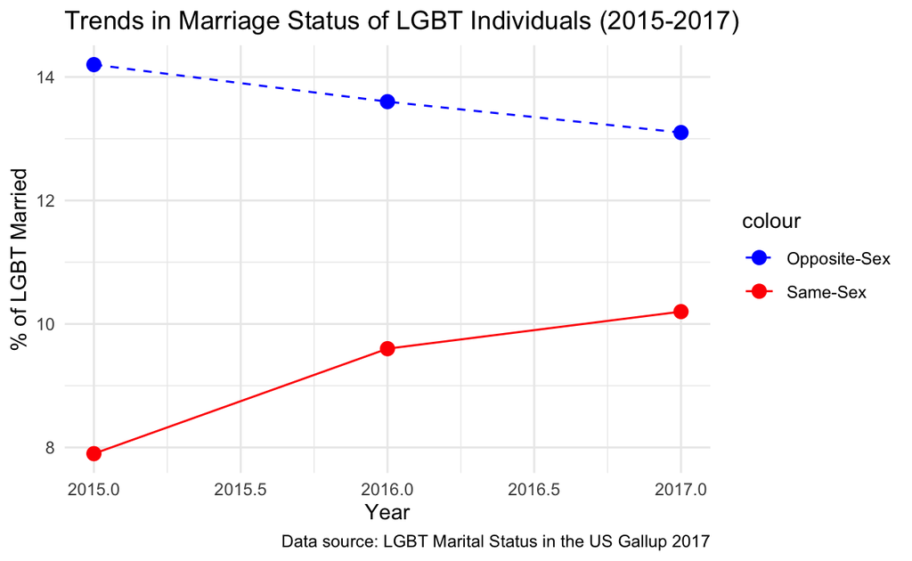

   ```r
   #Loading required packages
   library(ggplot2)
   #Creating the plot
   plot <- ggplot(lgbt_mariage,
                  aes(x = Year)) +
     geom_line(aes(y = `% LGBT Married to same-sex spouse`,
                   color = "Same-Sex"),
               linetype = "solid") +
     geom_line(aes(y = `% LGBT Married to opposite-sex spouse`,
                   color = "Opposite-Sex"),
               linetype = "dashed") +
     geom_point(data = lgbt_mariage %>%
                  filter(Year %in% c(2015, 2016, 2017)),
                aes(y = `% LGBT Married to same-sex spouse`,
                    color = "Same-Sex"),
                size = 3) +
     geom_point(data = lgbt_mariage %>%
                  filter(Year %in% c(2015, 2016, 2017)),
                aes(y = `% LGBT Married to opposite-sex spouse`,
                    color = "Opposite-Sex"),
                size = 3) +
     labs(x = "Year",
          y = "% of LGBT Married",
          title = "Trends in Marriage Status of LGBT Individuals (2015-2017)",
          caption = "Data source: LGBT Marital Status in the US Gallup 2017") + scale_color_manual(values = c("blue", "red")) +
     theme_minimal()

   #Printing the plot
   plot
   ```

## Final Note

Make sure to push all your commits and changes to GitHub before submittining the exercise sheet.